# EpiCompare Report

EpiCompare performs comparisons, benchmarking and QC of epigenetic datasets.

### Dataset summary

Peak File 1: encode  
Peak File 2: CUT&Tag

## Percentage Overlap

This function calculates the percentage of overlapping peaks in each file. By default, two peak ranges are considered as overlapping if:

- The start or end position of a range is inside the other range
- The overlap has a minimum distance of 1 base pair
- The overlap can be of any type (i.e. start, end, within, equal are all accepted)

Percentage of **encode** peaks found in **CUT&Tag** peaks:

```
## [1] 27.20416
```

Percentage of **CUT&Tag** peaks found in **encode** peaks:

```
## [1] 80.9453
```

## ChromHMM {.tabset}

ChromHMM annotates peaks with ChromHMM-derived chromatin states. The annotations for cell-line K562 were obtained from http://genome.ucsc.edu/cgi-bin/hgFileUi?g=wgEncodeBroadHmm&db=hg19. The heatmap shows the relative percentages of total peaks falling into each category. Note that peaks can fall into multiple categories simultaneously.

### Peak files

ChromHMM annotation of individual peak files.

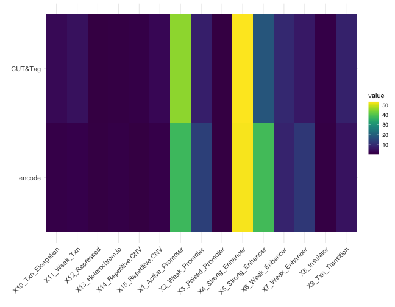

### Overlapping peaks

ChromHMM annotation of overlapping peaks in each file.

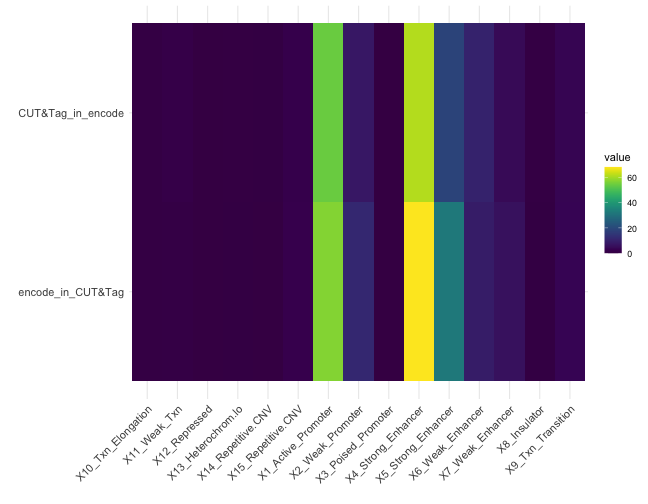

### Unique peaks

ChromHMM annotation of unique peaks in each file.

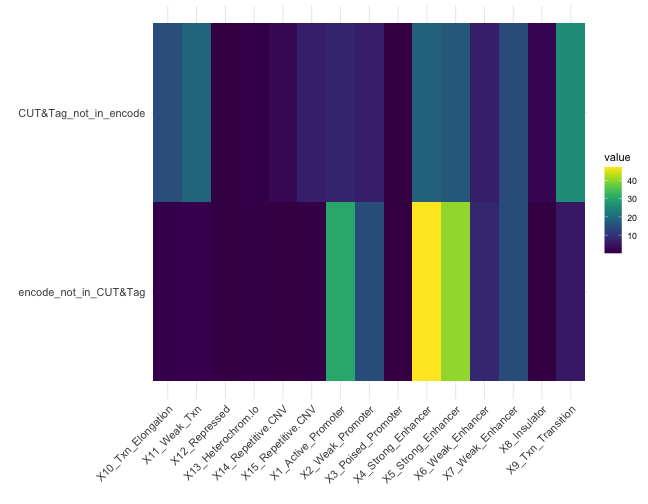